# Topic 3.3: Tree-Based Models

Decision Trees, Bagging, and Random Forests in R

Advanced Modelling, Master in Computational Social Science

UC3M, 2026

# 1 Introduction

In this notebook we will practice with the tree-based methods seen in topic 3.3.

- **Decision Trees**: simple, interpretable binary decision rules
- **Pruning**: controlling overfitting by simplifying the tree
- **Bagging**: averaging many trees grown on bootstrap resamples
- **Random Forests**: bagging plus random feature subsampling at each split

We will start with some small toy examples (`iris` and `mtcars`) to see what are the main R functions and their arguments, and then apply the full workflow to our real case study of student failure in mathematics as we did in topic 3.1.

```r
library(tidyverse)
library(tree)          # tree() and cv.tree() for decision trees
library(randomForest)  # randomForest() for bagging and random forests
library(caret)         # createDataPartition(), confusionMatrix()
```

# 2 Classification Tree (`iris`)

We use the classic Iris dataset (3 flower species, 4 numeric predictors) to learn the basic tree workflow. We start by creating a stratified train/test split with `caret`, and in this first example we focus on `Petal.Length` and `Petal.Width` so we can visualise the tree partition directly in 2D.

```r
data(iris)

set.seed(123)
iris_idx <- createDataPartition(iris$Species, p = 0.7, list = FALSE)
iris_train <- iris[iris_idx, ]
iris_test  <- iris[-iris_idx, ]

cat("Train:", nrow(iris_train), "| Test:", nrow(iris_test), "\n")
```

```
## Train: 105 | Test: 45
```

The main function is `tree()` from the `tree` package. Some of its arguments are:

- `formula`
- `data`
- `control = tree.control(...)` which governs how large the tree grows with the following parameters:
  - `nobs` (number of observations, required)
  - `mindev` (minimum deviance improvement required to attempt a split; smaller values grow bigger trees, default `0.01`)
  - `minsize` (minimum observations per terminal node, default `10`).

```r
iris_tree <- tree(
  Species ~ Petal.Length + Petal.Width,
  data    = iris_train,
  control = tree.control(
    nobs    = nrow(iris_train),
    mindev  = 0.01,   # lower = bigger tree
    minsize = 5       # min obs per leaf
  )
)

summary(iris_tree)
```

```
##
## Classification tree:
## tree(formula = Species ~ Petal.Length + Petal.Width, data = iris_train,
##     control = tree.control(nobs = nrow(iris_train), mindev = 0.01,
##         minsize = 5))
## Number of terminal nodes:  5
## Residual mean deviance:  0.03819 = 3.819 / 100
## Misclassification error rate: 0.009524 = 1 / 105
```

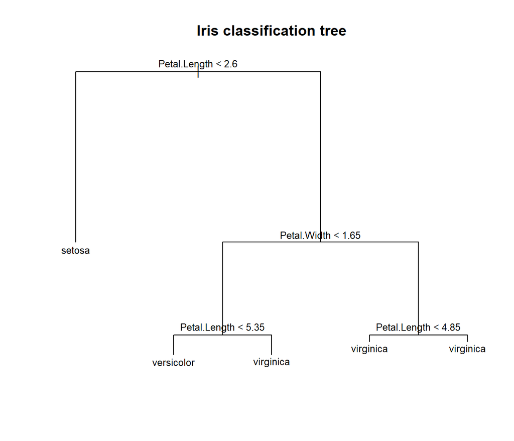

```r
plot(iris_tree)
text(iris_tree, pretty = 0, cex = 0.8)
title("Iris classification tree")
```

Each internal node shows the splitting variable and threshold; each leaf shows the predicted class.

Because we used two predictors, we can plot the feature-space partition induced by the tree.

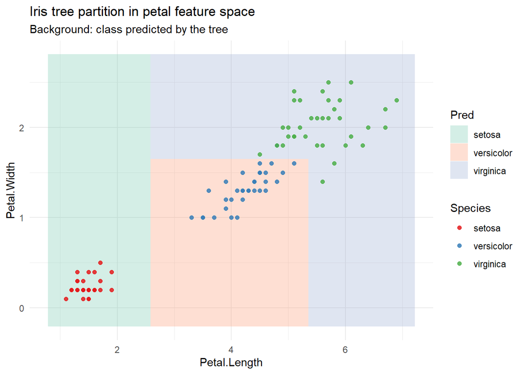

```r
iris_grid <- expand.grid(
  Petal.Length = seq(min(iris_train$Petal.Length) - 0.3,
                     max(iris_train$Petal.Length) + 0.3,
                     length.out = 200),
  Petal.Width  = seq(min(iris_train$Petal.Width) - 0.3,
                     max(iris_train$Petal.Width) + 0.3,
                     length.out = 200)
)

iris_grid$Pred <- predict(iris_tree, newdata = iris_grid, type = "class")

ggplot() +
  geom_tile(
    data = iris_grid,
    aes(x = Petal.Length, y = Petal.Width, fill = Pred),
    alpha = 0.28
  ) +
  geom_point(
    data = iris_train,
    aes(x = Petal.Length, y = Petal.Width, color = Species),
    size = 1.6,
    alpha = 0.85
  ) +
  labs(
    title = "Iris tree partition in petal feature space",
    subtitle = "Background: class predicted by the tree",
    x = "Petal.Length",
    y = "Petal.Width"
  ) +
  scale_fill_brewer(palette = "Set2") +
  scale_color_brewer(palette = "Set1") +
  theme_minimal()
```

To evaluate on the test set we use `predict()` with `type = "class"`, which returns the predicted class directly instead of the default probability matrix.

```r
iris_tree_pred <- predict(iris_tree, newdata = iris_test, type = "class")
confusionMatrix(iris_tree_pred, iris_test$Species)
```

```
## Confusion Matrix and Statistics
##
##             Reference
## Prediction   setosa versicolor virginica
##   setosa         15          0         0
##   versicolor      0         14         2
##   virginica       0          1        13
##
## Overall Statistics
##
##                Accuracy : 0.9333
##                  95% CI : (0.8173, 0.986)
##     No Information Rate : 0.3333
##     P-Value [Acc > NIR] : < 2.2e-16
##
##                   Kappa : 0.9
##
##  Mcnemar's Test P-Value : NA
##
## Statistics by Class:
##
##                      Class: setosa Class: versicolor Class: virginica
## Sensitivity                 1.0000            0.9333           0.8667
## Specificity                 1.0000            0.9333           0.9667
## Pos Pred Value              1.0000            0.8750           0.9286
## Neg Pred Value              1.0000            0.9655           0.9355
## Prevalence                  0.3333            0.3333           0.3333
## Detection Rate              0.3333            0.3111           0.2889
## Detection Prevalence        0.3333            0.3556           0.3111
## Balanced Accuracy           1.0000            0.9333           0.9167
```

A large tree may overfit. Pruning addresses this by first growing a full tree and then using cross-validation to select the number of leaves that minimises CV error. The workflow is:

1. Grow a large tree with `mindev = 0`
2. Run `cv.tree()` with `FUN = prune.misclass` to use misclassification error instead of deviance
3. Pick the size with the lowest CV error
4. Call `prune.misclass(big_tree, best = chosen_size)`.

The `cv.tree` object contains `$size` (number of terminal nodes), `$dev` (CV error), and `$k` (the regularisation penalty alpha).

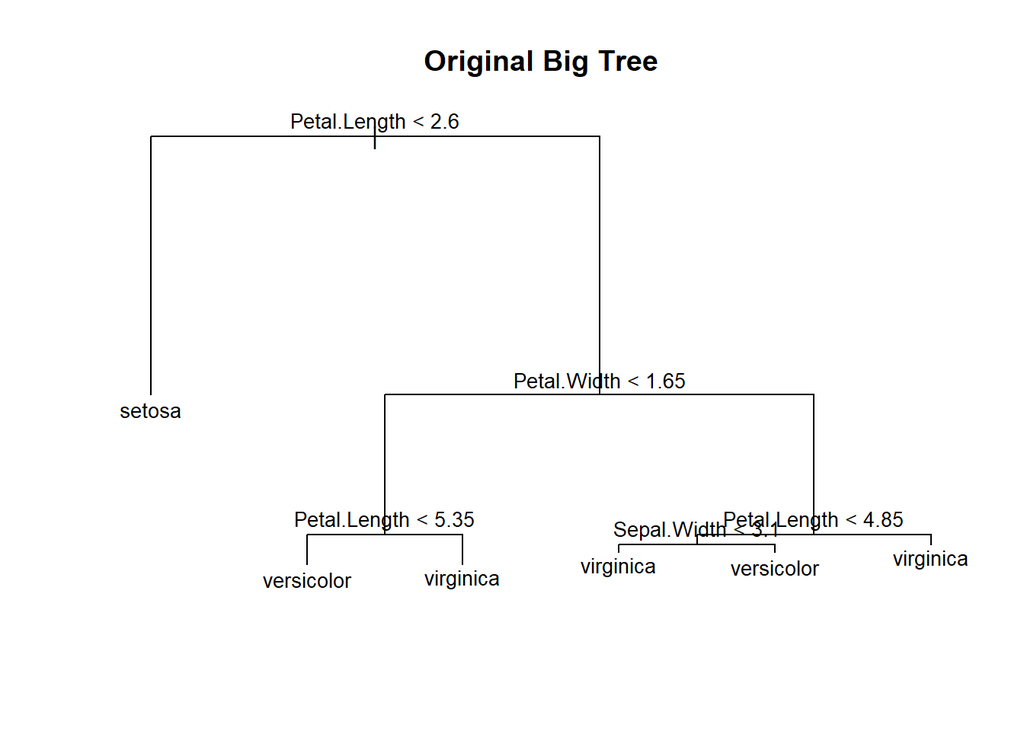

```r
iris_big <- tree(
  Species ~ .,
  data    = iris_train,
  control = tree.control(nobs = nrow(iris_train), mindev = 0, minsize = 2)
)

plot(iris_big)
text(iris_big, pretty = 0, cex = 0.85)
title(paste("Original Big Tree"))
```

```r
set.seed(3302)
iris_cv <- cv.tree(iris_big, FUN = prune.misclass)

# Show the results
iris_cv
```

```
## $size
## [1] 6 4 3 2 1
##
## $dev
## [1]  6  6  6 84 84
##
## $k
## [1] -Inf  0.5  2.0 32.0 35.0
##
## $method
## [1] "misclass"
##
## attr(,"class")
## [1] "prune"         "tree.sequence"
```

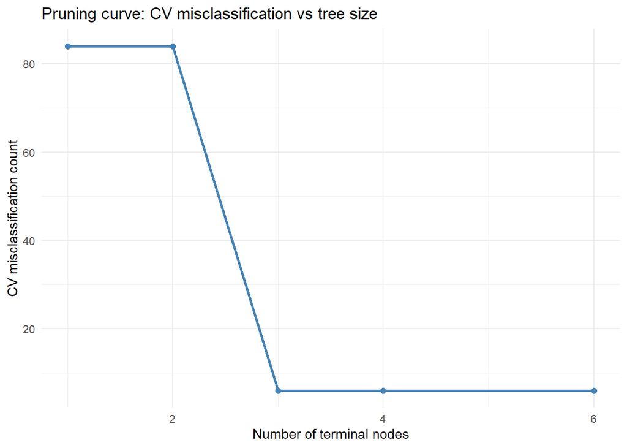

```r
# Create a plot
tibble(size = iris_cv$size, cv_error = iris_cv$dev) %>%
  ggplot(aes(x = size, y = cv_error)) +
  geom_line(color = "steelblue", linewidth = 1) +
  geom_point(color = "steelblue", size = 2) +
  labs(
    title = "Pruning curve: CV misclassification vs tree size",
    x = "Number of terminal nodes",
    y = "CV misclassification count"
  ) +
  theme_minimal()
```

```r
# Selecting the tree size with minimum CV error
best_size <- iris_cv$size[which.min(iris_cv$dev)]
cat("Best tree size (terminal nodes):", best_size, "\n")
```

```
## Best tree size (terminal nodes): 6
```

```r
# But this is the same size as the big one!
# In this case there are several values with minimum CV error
# We should then choose the smallest size one given that they have the same CV error
# The following code does precisely that
min_dev <- min(iris_cv$dev, na.rm = TRUE)
best_size <- min(iris_cv$size[iris_cv$dev == min_dev], na.rm = TRUE)
cat("Best tree size (terminal nodes):", best_size, "\n")
```

```
## Best tree size (terminal nodes): 3
```

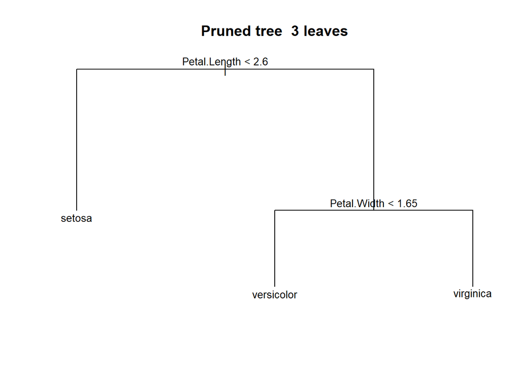

```r
iris_pruned <- prune.misclass(iris_big, best = best_size)

plot(iris_pruned)
text(iris_pruned, pretty = 0, cex = 0.85)
title(paste("Pruned tree ", best_size, "leaves"))
```

```r
iris_pruned_pred <- predict(iris_pruned, newdata = iris_test, type = "class")
confusionMatrix(iris_pruned_pred, iris_test$Species)
```

```
## Confusion Matrix and Statistics
##
##             Reference
## Prediction   setosa versicolor virginica
##   setosa         15          0         0
##   versicolor      0         14         2
##   virginica       0          1        13
##
## Overall Statistics
##
##                Accuracy : 0.9333
##                  95% CI : (0.8173, 0.986)
##     No Information Rate : 0.3333
##     P-Value [Acc > NIR] : < 2.2e-16
##
##                   Kappa : 0.9
##
##  Mcnemar's Test P-Value : NA
##
## Statistics by Class:
##
##                      Class: setosa Class: versicolor Class: virginica
## Sensitivity                 1.0000            0.9333           0.8667
## Specificity                 1.0000            0.9333           0.9667
## Pos Pred Value              1.0000            0.8750           0.9286
## Neg Pred Value              1.0000            0.9655           0.9355
## Prevalence                  0.3333            0.3333           0.3333
## Detection Rate              0.3333            0.3111           0.2889
## Detection Prevalence        0.3333            0.3556           0.3111
## Balanced Accuracy           1.0000            0.9333           0.9167
```

You can see how the accuracy is the same as the unprunned tree, but its smaller in size and therefore more interpretable.

# 3 Bagging and Random Forest (`iris`)

To use bagging, we saw that its indeed an special case of a random forest where `m = p`. Therefore both methods come from the `randomForest` package and share the same interface, where the key argument is `mtry`, the number of candidate predictors randomly sampled at each split. Setting `mtry = p` (all predictors) gives **bagging**, while `mtry = floor(sqrt(p))` (the default for classification) gives a **random forest**. The argument `ntree` controls the total number of trees (default 500; more trees are rarely harmful as it will not overfit due to the averaging, just slower), and `importance = TRUE` enables variable importance computation.

Starting with bagging we will fit 500 trees, each seeing all 4 predictors at every split (`m=p`).

```r
p <- ncol(iris_train) - 1   # number of predictors

set.seed(3303)
iris_bag <- randomForest(
  Species   ~ .,
  data       = iris_train,
  mtry       = p,           # bagging: use ALL predictors at each split
  ntree      = 500,
  importance = TRUE
)

iris_bag   # prints OOB confusion matrix and error
```

```
##
## Call:
##  randomForest(formula = Species ~ ., data = iris_train, mtry = p,      ntree = 500, importance = TRUE)
##                Type of random forest: classification
##                      Number of trees: 500
## No. of variables tried at each split: 4
##
##         OOB estimate of  error rate: 4.76%
## Confusion matrix:
##            setosa versicolor virginica class.error
## setosa         35          0         0  0.00000000
## versicolor      0         33         2  0.05714286
## virginica       0          3        32  0.08571429
```

Remember that the **OOB (out-of-bag) error** printed by the model is a built-in estimate of test error at no extra cost: each tree only uses ~63 % of training cases, so the remaining ~37 % act as a held-out set for that tree. Therefore we dont have the need to explicitly use cross-validation

```r
iris_bag_pred <- predict(iris_bag, newdata = iris_test, type = "class")
confusionMatrix(iris_bag_pred, iris_test$Species)
```

```
## Confusion Matrix and Statistics
##
##             Reference
## Prediction   setosa versicolor virginica
##   setosa         15          0         0
##   versicolor      0         14         2
##   virginica       0          1        13
##
## Overall Statistics
##
##                Accuracy : 0.9333
##                  95% CI : (0.8173, 0.986)
##     No Information Rate : 0.3333
##     P-Value [Acc > NIR] : < 2.2e-16
##
##                   Kappa : 0.9
##
##  Mcnemar's Test P-Value : NA
##
## Statistics by Class:
##
##                      Class: setosa Class: versicolor Class: virginica
## Sensitivity                 1.0000            0.9333           0.8667
## Specificity                 1.0000            0.9333           0.9667
## Pos Pred Value              1.0000            0.8750           0.9286
## Neg Pred Value              1.0000            0.9655           0.9355
## Prevalence                  0.3333            0.3333           0.3333
## Detection Rate              0.3333            0.3111           0.2889
## Detection Prevalence        0.3333            0.3556           0.3111
## Balanced Accuracy           1.0000            0.9333           0.9167
```

Now we fit the random forest, reducing `mtry` to `floor(sqrt(p))` so that only a random subset of features is considered at each split. This decorrelates the trees and typically improves the ensemble.

```r
set.seed(3304)
iris_rf <- randomForest(
  Species   ~ .,
  data      = iris_train,
  mtry      = floor(sqrt(p)),  # default: sqrt(p) for classification
  ntree     = 500,
  importance = TRUE
)

iris_rf
```

```
##
## Call:
##  randomForest(formula = Species ~ ., data = iris_train, mtry = floor(sqrt(p)),      ntree = 500, importance = TRUE)
##                Type of random forest: classification
##                      Number of trees: 500
## No. of variables tried at each split: 2
##
##         OOB estimate of  error rate: 4.76%
## Confusion matrix:
##            setosa versicolor virginica class.error
## setosa         35          0         0  0.00000000
## versicolor      0         33         2  0.05714286
## virginica       0          3        32  0.08571429
```

```r
iris_rf_pred <- predict(iris_rf, newdata = iris_test, type = "class")
confusionMatrix(iris_rf_pred, iris_test$Species)
```

```
## Confusion Matrix and Statistics
##
##             Reference
## Prediction   setosa versicolor virginica
##   setosa         15          0         0
##   versicolor      0         14         2
##   virginica       0          1        13
##
## Overall Statistics
##
##                Accuracy : 0.9333
##                  95% CI : (0.8173, 0.986)
##     No Information Rate : 0.3333
##     P-Value [Acc > NIR] : < 2.2e-16
##
##                   Kappa : 0.9
##
##  Mcnemar's Test P-Value : NA
##
## Statistics by Class:
##
##                      Class: setosa Class: versicolor Class: virginica
## Sensitivity                 1.0000            0.9333           0.8667
## Specificity                 1.0000            0.9333           0.9667
## Pos Pred Value              1.0000            0.8750           0.9286
## Neg Pred Value              1.0000            0.9655           0.9355
## Prevalence                  0.3333            0.3333           0.3333
## Detection Rate              0.3333            0.3111           0.2889
## Detection Prevalence        0.3333            0.3556           0.3111
## Balanced Accuracy           1.0000            0.9333           0.9167
```

In this case, as `iris` is a very simple dataset we get the same accuracy with all the models, but we will later see how this changes in more complex datasets.

With `importance = TRUE` we can inspect which variables mattered most. `importance()` returns two types of scores: **MeanDecreaseAccuracy** (`type = 1`) measures how much accuracy drops when each variable is permuted at random (higher = more important), and **MeanDecreaseGini** (`type = 2`) sums the total node impurity decrease from splits on that variable across all trees. `varImpPlot()` visualises both at once.

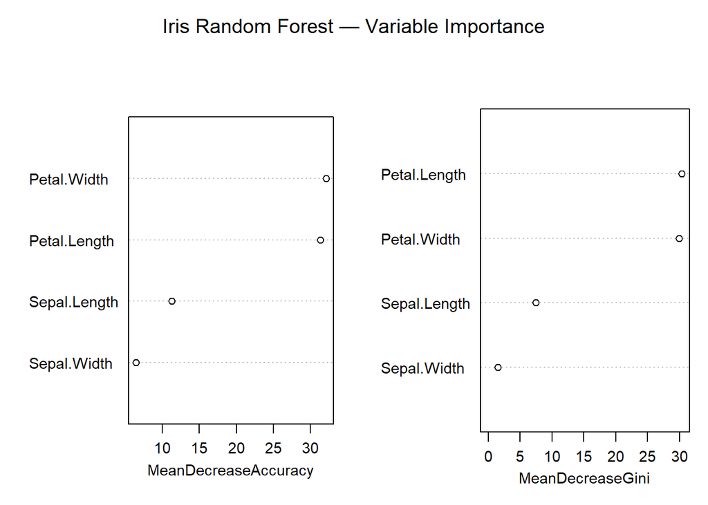

```r
varImpPlot(iris_rf, main = "Iris Random Forest — Variable Importance", cex = 0.9)
```

# 4 Regression Tree (mtcars)

We have been using tree-based models with classification examples but trees also work for **continuous targets**. The syntax is identical: `predict()` then returns a numeric vector and the tree minimises residual sum of squares (RSS) at each split instead of impurity. We use `mtcars` to predict fuel efficiency (`mpg`) from the other car features.

```r
data(mtcars)
set.seed(456)
mt_idx   <- createDataPartition(mtcars$mpg, p = 0.75, list = FALSE)
mt_train <- mtcars[mt_idx, ]
mt_test  <- mtcars[-mt_idx, ]
```

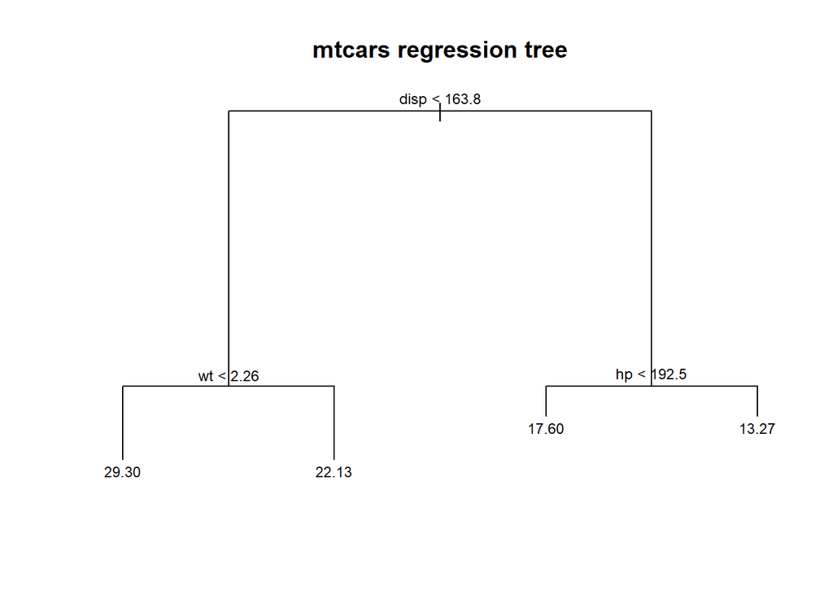

```r
mt_tree <- tree(mpg ~ ., data = mt_train)

plot(mt_tree)
text(mt_tree, cex = 0.75)
title("mtcars regression tree")
```

To see clearly how regression trees create piecewise-constant predictions, we fit a one-predictor tree (`mpg ~ wt`) and draw its fitted values as a step function.

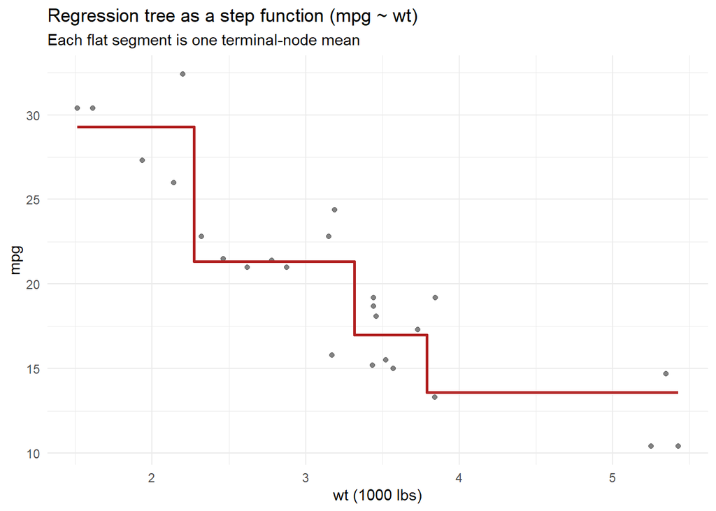

```r
mt_tree_wt <- tree(mpg ~ wt, data = mt_train)

wt_grid <- tibble(
  wt = seq(min(mt_train$wt), max(mt_train$wt), length.out = 300)
) %>%
  mutate(mpg_hat = predict(mt_tree_wt, newdata = .))

ggplot(mt_train, aes(x = wt, y = mpg)) +
  geom_point(color = "grey35", alpha = 0.75) +
  geom_step(
    data = wt_grid,
    aes(x = wt, y = mpg_hat),
    color = "firebrick",
    linewidth = 1
  ) +
  labs(
    title = "Regression tree as a step function (mpg ~ wt)",
    subtitle = "Each flat segment is one terminal-node mean",
    x = "wt (1000 lbs)",
    y = "mpg"
  ) +
  theme_minimal()
```

```r
mt_pred <- predict(mt_tree, newdata = mt_test)

rmse <- sqrt(mean((mt_pred - mt_test$mpg)^2))
cat("Test RMSE:", round(rmse, 3), "\n")
```

```
## Test RMSE: 2.667
```

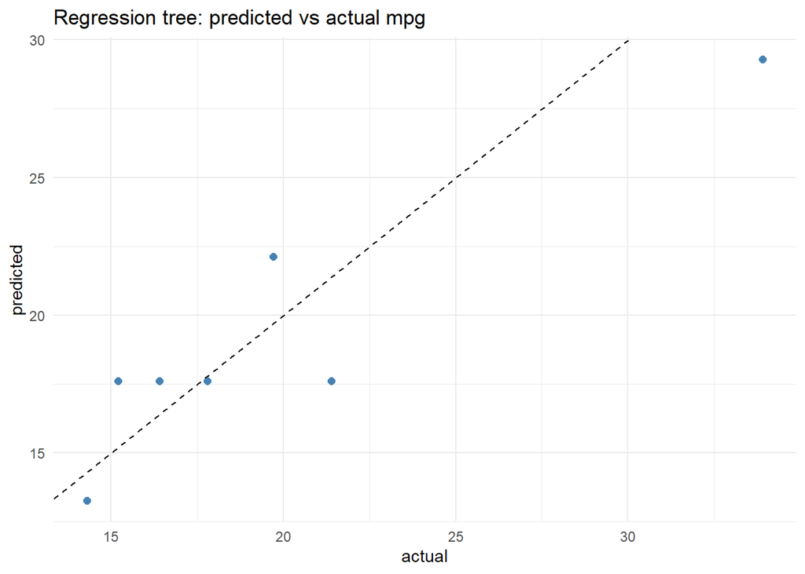

```r
tibble(actual = mt_test$mpg, predicted = mt_pred) %>%
  ggplot(aes(x = actual, y = predicted)) +
  geom_point(size = 2, color = "steelblue") +
  geom_abline(slope = 1, intercept = 0, linetype = "dashed") +
  labs(title = "Regression tree: predicted vs actual mpg") +
  theme_minimal()
```

# 5 Real Case Study: Student Failure

Now we apply the full workflow to the student failure dataset introduced in topic 3.1. The goal is to predict whether a student **fails mathematics** (final grade `G3 < 5`). We work with the same compact feature set used before: `failures`, `absences`, `studytime`, `Medu`, `Fedu`, `Walc`, `goout`, and `age`. Please refer to the topic 3.1 notebook for the full variable descriptions and background.

```r
math_raw <- read.csv2("student-mat.csv",
  stringsAsFactors = TRUE
)

dim(math_raw)
```

```
## [1] 395  33
```

```r
summary(math_raw$G3)
```

```
##    Min. 1st Qu.  Median    Mean 3rd Qu.    Max.
##    0.00    8.00   11.00   10.42   14.00   20.00
```

```r
math <- math_raw %>%
  mutate(Fail = factor(G3 < 5, levels = c(FALSE, TRUE), labels = c("No", "Yes"))) %>%
  dplyr::select(Fail, failures, absences, studytime, Medu, Fedu, Walc, goout, age)

summary(math)
```

```
##   Fail        failures         absences        studytime          Medu
##  No :356   Min.   :0.0000   Min.   : 0.000   Min.   :1.000   Min.   :0.000
##  Yes: 39   1st Qu.:0.0000   1st Qu.: 0.000   1st Qu.:1.000   1st Qu.:2.000
##            Median :0.0000   Median : 4.000   Median :2.000   Median :3.000
##            Mean   :0.3342   Mean   : 5.709   Mean   :2.035   Mean   :2.749
##            3rd Qu.:0.0000   3rd Qu.: 8.000   3rd Qu.:2.000   3rd Qu.:4.000
##            Max.   :3.0000   Max.   :75.000   Max.   :4.000   Max.   :4.000
##       Fedu            Walc           goout            age
##  Min.   :0.000   Min.   :1.000   Min.   :1.000   Min.   :15.0
##  1st Qu.:2.000   1st Qu.:1.000   1st Qu.:2.000   1st Qu.:16.0
##  Median :2.000   Median :2.000   Median :3.000   Median :17.0
##  Mean   :2.522   Mean   :2.291   Mean   :3.109   Mean   :16.7
##  3rd Qu.:3.000   3rd Qu.:3.000   3rd Qu.:4.000   3rd Qu.:18.0
##  Max.   :4.000   Max.   :5.000   Max.   :5.000   Max.   :22.0
```

```r
prop.table(table(math$Fail))
```

```
##
##         No        Yes
## 0.90126582 0.09873418
```

We do a stratified 80/20 split to preserve class proportions in both sets.

```r
set.seed(2026)
in_train <- createDataPartition(math$Fail, p = 0.8, list = FALSE)
train_df <- math[in_train, ]
test_df  <- math[-in_train, ]

cat("Train:", nrow(train_df), "| Test:", nrow(test_df), "\n")
```

```
## Train: 317 | Test: 78
```

```r
cat("Train failure rate:", round(mean(train_df$Fail == "Yes"), 3), "\n")
```

```
## Train failure rate: 0.101
```

```r
cat("Test  failure rate:", round(mean(test_df$Fail  == "Yes"), 3), "\n")
```

```
## Test  failure rate: 0.09
```

We fit a decision tree first. The tree will automatically select which variables to split on and in what order.

```r
student_tree <- tree(
  Fail ~ .,
  data    = train_df,
  control = tree.control(nobs = nrow(train_df), mindev = 0.01, minsize = 10)
)

summary(student_tree)
```

```
##
## Classification tree:
## tree(formula = Fail ~ ., data = train_df, control = tree.control(nobs = nrow(train_df),
##     mindev = 0.01, minsize = 10))
## Variables actually used in tree construction:
## [1] "absences" "failures" "Walc"     "goout"    "Fedu"     "age"      "Medu"
## Number of terminal nodes:  11
## Residual mean deviance:  0.1893 = 57.93 / 306
## Misclassification error rate: 0.04101 = 13 / 317
```

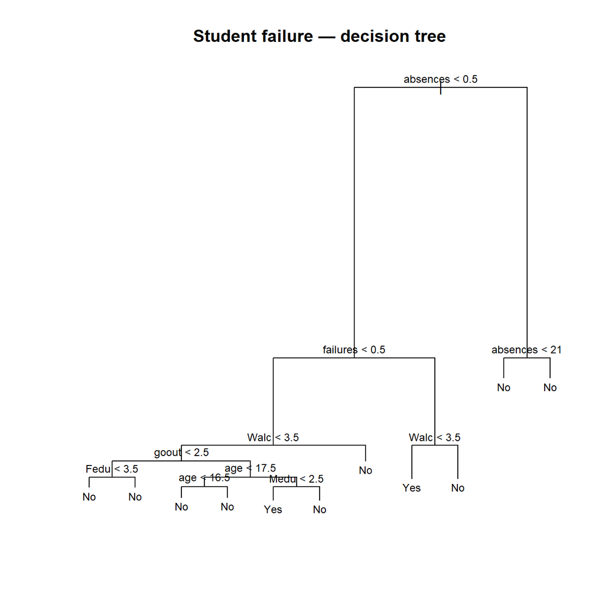

```r
plot(student_tree)
text(student_tree, pretty = 0, cex = 0.75)
title("Student failure — decision tree")
```

```r
student_tree_pred <- predict(student_tree, newdata = test_df, type = "class")
cm_tree <- confusionMatrix(student_tree_pred, test_df$Fail, positive = "Yes")
cm_tree
```

```
## Confusion Matrix and Statistics
##
##           Reference
## Prediction No Yes
##        No  68   5
##        Yes  3   2
##
##                Accuracy : 0.8974
##                  95% CI : (0.8079, 0.9547)
##     No Information Rate : 0.9103
##     P-Value [Acc > NIR] : 0.7355
##
##                   Kappa : 0.2794
##
##  Mcnemar's Test P-Value : 0.7237
##
##             Sensitivity : 0.28571
##             Specificity : 0.95775
##          Pos Pred Value : 0.40000
##          Neg Pred Value : 0.93151
##              Prevalence : 0.08974
##          Detection Rate : 0.02564
##    Detection Prevalence : 0.06410
##       Balanced Accuracy : 0.62173
##
##        'Positive' Class : Yes
##
```

To guard against overfitting we run the same pruning workflow: grow a maximal tree, cross-validate to find the optimal size, then prune back.

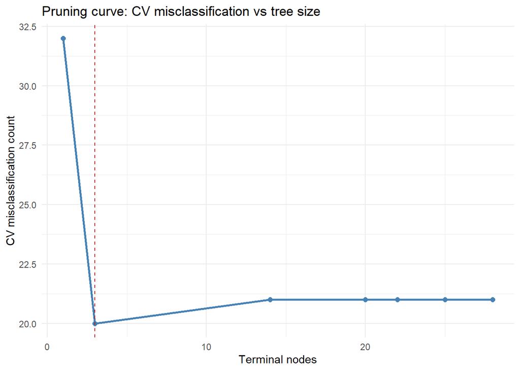

```r
student_big <- tree(
  Fail ~ .,
  data    = train_df,
  control = tree.control(nobs = nrow(train_df), mindev = 0, minsize = 2)
)

set.seed(3305)
student_cv <- cv.tree(student_big, FUN = prune.misclass)

tibble(size = student_cv$size, cv_error = student_cv$dev) %>%
  ggplot(aes(x = size, y = cv_error)) +
  geom_line(color = "steelblue", linewidth = 1) +
  geom_point(color = "steelblue", size = 2) +
  geom_vline(
    xintercept = student_cv$size[which.min(student_cv$dev)],
    linetype = "dashed", color = "firebrick"
  ) +
  labs(
    title = "Pruning curve: CV misclassification vs tree size",
    x = "Terminal nodes", y = "CV misclassification count"
  ) +
  theme_minimal()
```

```r
best_size <- student_cv$size[which.min(student_cv$dev)]
cat("Best size:", best_size, "\n")
```

```
## Best size: 3
```

```r
student_pruned      <- prune.misclass(student_big, best = best_size)
student_pruned_pred <- predict(student_pruned, newdata = test_df, type = "class")
cm_pruned <- confusionMatrix(student_pruned_pred, test_df$Fail, positive = "Yes")
cm_pruned
```

```
## Confusion Matrix and Statistics
##
##           Reference
## Prediction No Yes
##        No  68   4
##        Yes  3   3
##
##                Accuracy : 0.9103
##                  95% CI : (0.8238, 0.9632)
##     No Information Rate : 0.9103
##     P-Value [Acc > NIR] : 0.5988
##
##                   Kappa : 0.4129
##
##  Mcnemar's Test P-Value : 1.0000
##
##             Sensitivity : 0.42857
##             Specificity : 0.95775
##          Pos Pred Value : 0.50000
##          Neg Pred Value : 0.94444
##              Prevalence : 0.08974
##          Detection Rate : 0.03846
##    Detection Prevalence : 0.07692
##       Balanced Accuracy : 0.69316
##
##        'Positive' Class : Yes
##
```

We now move to ensemble methods. For bagging we set `mtry = p` so all predictors are candidates at every split; for the random forest we use `mtry = floor(sqrt(p))` to decorrelate trees. Both models print the OOB error matrix directly.

```r
p_student <- ncol(train_df) - 1

set.seed(3306)
student_bag <- randomForest(
  Fail       ~ .,
  data       = train_df,
  mtry       = p_student,   # bagging: all predictors
  ntree      = 500,
  importance = TRUE
)

student_bag
```

```
##
## Call:
##  randomForest(formula = Fail ~ ., data = train_df, mtry = p_student,      ntree = 500, importance = TRUE)
##                Type of random forest: classification
##                      Number of trees: 500
## No. of variables tried at each split: 8
##
##         OOB estimate of  error rate: 6.31%
## Confusion matrix:
##      No Yes class.error
## No  278   7   0.0245614
## Yes  13  19   0.4062500
```

```r
student_bag_pred <- predict(student_bag, newdata = test_df, type = "class")
cm_bag <- confusionMatrix(student_bag_pred, test_df$Fail, positive = "Yes")
cm_bag
```

```
## Confusion Matrix and Statistics
##
##           Reference
## Prediction No Yes
##        No  65   5
##        Yes  6   2
##
##                Accuracy : 0.859
##                  95% CI : (0.7617, 0.9274)
##     No Information Rate : 0.9103
##     P-Value [Acc > NIR] : 0.955
##
##                   Kappa : 0.189
##
##  Mcnemar's Test P-Value : 1.000
##
##             Sensitivity : 0.28571
##             Specificity : 0.91549
##          Pos Pred Value : 0.25000
##          Neg Pred Value : 0.92857
##              Prevalence : 0.08974
##          Detection Rate : 0.02564
##    Detection Prevalence : 0.10256
##       Balanced Accuracy : 0.60060
##
##        'Positive' Class : Yes
##
```

```r
set.seed(3307)
student_rf <- randomForest(
  Fail       ~ .,
  data       = train_df,
  mtry       = floor(sqrt(p_student)),
  ntree      = 500,
  importance = TRUE
)

student_rf
```

```
##
## Call:
##  randomForest(formula = Fail ~ ., data = train_df, mtry = floor(sqrt(p_student)),      ntree = 500, importance = TRUE)
##                Type of random forest: classification
##                      Number of trees: 500
## No. of variables tried at each split: 2
##
##         OOB estimate of  error rate: 5.36%
## Confusion matrix:
##      No Yes class.error
## No  284   1 0.003508772
## Yes  16  16 0.500000000
```

```r
student_rf_pred <- predict(student_rf, newdata = test_df, type = "class")
cm_rf <- confusionMatrix(student_rf_pred, test_df$Fail, positive = "Yes")
cm_rf
```

```
## Confusion Matrix and Statistics
##
##           Reference
## Prediction No Yes
##        No  68   5
##        Yes  3   2
##
##                Accuracy : 0.8974
##                  95% CI : (0.8079, 0.9547)
##     No Information Rate : 0.9103
##     P-Value [Acc > NIR] : 0.7355
##
##                   Kappa : 0.2794
##
##  Mcnemar's Test P-Value : 0.7237
##
##             Sensitivity : 0.28571
##             Specificity : 0.95775
##          Pos Pred Value : 0.40000
##          Neg Pred Value : 0.93151
##              Prevalence : 0.08974
##          Detection Rate : 0.02564
##    Detection Prevalence : 0.06410
##       Balanced Accuracy : 0.62173
##
##        'Positive' Class : Yes
##
```

A useful diagnostic for the random forest is to plot the OOB error as a function of the number of trees, to check whether 500 trees was sufficient for the estimate to stabilise.

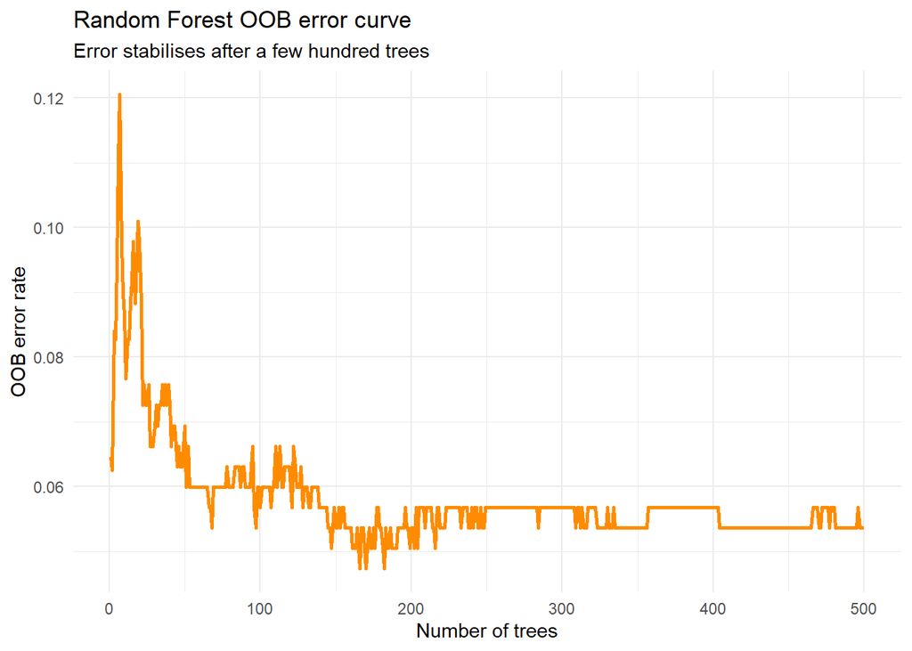

```r
tibble(
  trees     = seq_len(nrow(student_rf$err.rate)),
  oob_error = student_rf$err.rate[, "OOB"]
) %>%
  ggplot(aes(x = trees, y = oob_error)) +
  geom_line(color = "darkorange", linewidth = 1) +
  labs(
    title    = "Random Forest OOB error curve",
    subtitle = "Error stabilises after a few hundred trees",
    x = "Number of trees", y = "OOB error rate"
  ) +
  theme_minimal()
```

With all four models fitted we can now compare their test-set performance in one table. Because the classes are imbalanced, we report **Balanced Accuracy** alongside raw accuracy — a model that always predicts “No failure” would score high accuracy but zero sensitivity.

```r
extract_metrics <- function(cm, model_name) {
  tibble(
    Model               = model_name,
    Accuracy            = as.numeric(cm$overall["Accuracy"]),
    Sensitivity         = as.numeric(cm$byClass["Sensitivity"]),
    Specificity         = as.numeric(cm$byClass["Specificity"]),
    `Balanced Accuracy` = as.numeric(cm$byClass["Balanced Accuracy"])
  )
}

results <- bind_rows(
  extract_metrics(cm_tree,   "Decision tree"),
  extract_metrics(cm_pruned, "Pruned tree"),
  extract_metrics(cm_bag,    "Bagging"),
  extract_metrics(cm_rf,     "Random Forest")
)

knitr::kable(results, digits = 3)
```

| Model | Accuracy | Sensitivity | Specificity | Balanced Accuracy |
| --- | --- | --- | --- | --- |
| Decision tree | 0.897 | 0.286 | 0.958 | 0.622 |
| Pruned tree | 0.910 | 0.429 | 0.958 | 0.693 |
| Bagging | 0.859 | 0.286 | 0.915 | 0.601 |
| Random Forest | 0.897 | 0.286 | 0.958 | 0.622 |

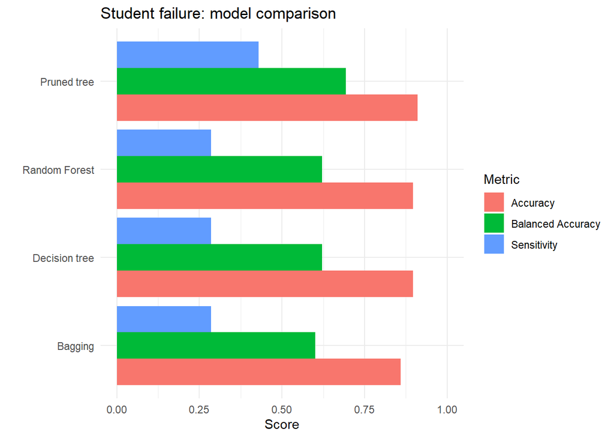

```r
results %>%
  dplyr::select(Model, Accuracy, `Balanced Accuracy`, Sensitivity) %>%
  pivot_longer(cols = -Model, names_to = "Metric", values_to = "Value") %>%
  ggplot(aes(x = reorder(Model, Value), y = Value, fill = Metric)) +
  geom_col(position = "dodge") +
  coord_flip() +
  ylim(0, 1) +
  labs(title = "Student failure: model comparison", x = "", y = "Score") +
  theme_minimal()
```

Finally, we inspect variable importance from the random forest. `varImpPlot()` shows both the permutation-based score (MeanDecreaseAccuracy, `type = 1`) and the Gini-based score (MeanDecreaseGini, `type = 2`). Note that importance ranks variables by predictive contribution, not causal effect — correlated variables can share or swap importance values.

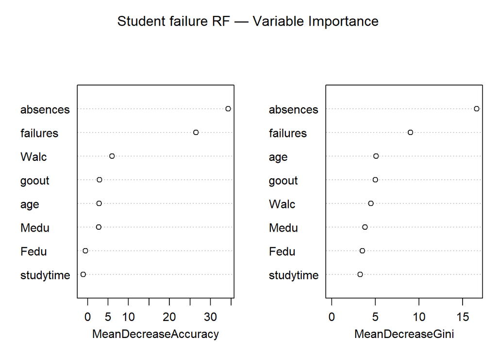

```r
varImpPlot(
  student_rf,
  main = "Student failure RF — Variable Importance"
)
```

```r
importance(student_rf, type = 1) %>%
  as.data.frame() %>%
  rownames_to_column("Variable") %>%
  arrange(desc(MeanDecreaseAccuracy)) %>%
  knitr::kable(digits = 3)
```

| Variable | MeanDecreaseAccuracy |
| --- | --- |
| absences | 34.344 |
| failures | 26.449 |
| Walc | 6.019 |
| goout | 2.932 |
| age | 2.823 |
| Medu | 2.730 |
| Fedu | -0.512 |
| studytime | -1.080 |

# 6 What about predicting probabilities?

What about setting a different threshold? Remember what we saw about imbalanced data in classification, where the problem can be partly fixed by choosing a threshold different from 0.5.

For the `tree` package, class probabilities are obtained with `predict(..., type = "vector")` (while `type = "class"` returns only the hard class). Below we reuse the first Iris tree example and compare both outputs.

```r
# Hard class predictions from the first iris tree section
iris_tree_class <- predict(iris_tree, newdata = iris_test, type = "class")

# Probability matrix (one column per species)
iris_tree_prob <- predict(iris_tree, newdata = iris_test, type = "vector")

# Recover class labels from probabilities via argmax
iris_tree_from_prob <- colnames(iris_tree_prob)[max.col(iris_tree_prob, ties.method = "first")]
iris_tree_from_prob <- factor(iris_tree_from_prob, levels = levels(iris_test$Species))

cat("Hard class == argmax(probabilities):", all(iris_tree_class == iris_tree_from_prob), "\n")
```

```
## Hard class == argmax(probabilities): TRUE
```

```r
bind_cols(
  tibble(true_species = iris_test$Species, pred_class = iris_tree_class),
  as_tibble(iris_tree_prob) %>% rename_with(~ paste0("p_", .x))
) %>%
  # slice_head(n = 10) %>%
  knitr::kable(digits = 3)
```

| true_species | pred_class | p_setosa | p_versicolor | p_virginica |
| --- | --- | --- | --- | --- |
| setosa | setosa | 1 | 0.000 | 0.000 |
| setosa | setosa | 1 | 0.000 | 0.000 |
| setosa | setosa | 1 | 0.000 | 0.000 |
| setosa | setosa | 1 | 0.000 | 0.000 |
| setosa | setosa | 1 | 0.000 | 0.000 |
| setosa | setosa | 1 | 0.000 | 0.000 |
| setosa | setosa | 1 | 0.000 | 0.000 |
| setosa | setosa | 1 | 0.000 | 0.000 |
| setosa | setosa | 1 | 0.000 | 0.000 |
| setosa | setosa | 1 | 0.000 | 0.000 |
| setosa | setosa | 1 | 0.000 | 0.000 |
| setosa | setosa | 1 | 0.000 | 0.000 |
| setosa | setosa | 1 | 0.000 | 0.000 |
| setosa | setosa | 1 | 0.000 | 0.000 |
| setosa | setosa | 1 | 0.000 | 0.000 |
| versicolor | versicolor | 0 | 1.000 | 0.000 |
| versicolor | versicolor | 0 | 1.000 | 0.000 |
| versicolor | versicolor | 0 | 1.000 | 0.000 |
| versicolor | versicolor | 0 | 1.000 | 0.000 |
| versicolor | versicolor | 0 | 1.000 | 0.000 |
| versicolor | versicolor | 0 | 1.000 | 0.000 |
| versicolor | virginica | 0 | 0.000 | 1.000 |
| versicolor | versicolor | 0 | 1.000 | 0.000 |
| versicolor | versicolor | 0 | 1.000 | 0.000 |
| versicolor | versicolor | 0 | 1.000 | 0.000 |
| versicolor | versicolor | 0 | 1.000 | 0.000 |
| versicolor | versicolor | 0 | 1.000 | 0.000 |
| versicolor | versicolor | 0 | 1.000 | 0.000 |
| versicolor | versicolor | 0 | 1.000 | 0.000 |
| versicolor | versicolor | 0 | 1.000 | 0.000 |
| virginica | virginica | 0 | 0.000 | 1.000 |
| virginica | virginica | 0 | 0.000 | 1.000 |
| virginica | virginica | 0 | 0.000 | 1.000 |
| virginica | virginica | 0 | 0.000 | 1.000 |
| virginica | virginica | 0 | 0.000 | 1.000 |
| virginica | virginica | 0 | 0.000 | 1.000 |
| virginica | versicolor | 0 | 1.000 | 0.000 |
| virginica | virginica | 0 | 0.000 | 1.000 |
| virginica | virginica | 0 | 0.333 | 0.667 |
| virginica | virginica | 0 | 0.000 | 1.000 |
| virginica | versicolor | 0 | 1.000 | 0.000 |
| virginica | virginica | 0 | 0.000 | 1.000 |
| virginica | virginica | 0 | 0.000 | 1.000 |
| virginica | virginica | 0 | 0.000 | 1.000 |
| virginica | virginica | 0 | 0.000 | 1.000 |

# 7 Some R packages for tree-based models

- **`tree`**: lightweight package for classification and regression trees with cross-validation pruning.
- **`rpart`** + **`rpart.plot`**: more feature-rich alternative for decision trees with nicer visualisation.
- **`randomForest`**: the classic implementation of bagging and random forests.
- **`ranger`**: faster, parallelised random forest with the same interface as `randomForest`.
- **`xgboost`** / **`lightgbm`**: gradient boosting: a more advanced ensemble strategy.
- **`caret`** / **`tidymodels`**: unified interfaces that wrap all the above for cross-validation, hyperparameter tuning, and pipelines.

# 8 Practice suggestion

Try to replicate the study with the Portugese subject dataset:

```r
por_raw <- read.csv2("student-por.csv",
  stringsAsFactors = TRUE
)

por <- por_raw %>%
  mutate(Fail = factor(G3 < 5, levels = c(FALSE, TRUE), labels = c("No", "Yes"))) %>%
  dplyr::select(Fail, failures, absences, studytime, Medu, Fedu, Walc, goout, age)

summary(por)
prop.table(table(por$Fail))
```